# Supervised Techniques

## Pixel Classification

The intent of the classification process is to categorize all pixels in a digital image into one of several land cover classes, or "themes". This categorized data may then be used to produce thematic maps of the land cover present in an image. Normally, multispectral data are used to perform the classification and, indeed, the spectral pattern present within the data for each pixel is used as the numerical basis for categorization (Lillesand and Kiefer, 1994). The objective of image classification is to identify and portray, as a unique gray level (or color), the features occurring in an image in terms of the object or type of land cover these features actually represent on the ground.

With supervised classification, we identify examples of the Information classes (i.e., land cover type) of interest in the image. These are called "training sites". The image processing software system is then used to develop a statistical characterization of the reflectance for each information class. This stage is often called "signature analysis" and may involve developing a characterization as simple as the mean or the rage of reflectance on each bands, or as complex as detailed analyses of the mean, variances and covariance over all bands. Once a statistical characterization has been achieved for each information class, the image is then classified by examining the reflectance for each pixel and making a decision about which of the signatures it resembles most.

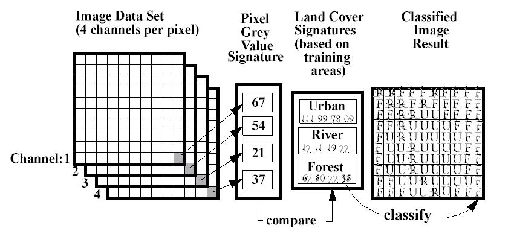

Principle of supervised learning for remote sensing data.

- Each pixel is associated to features (ex: the spectral bands) AND known labels Y.
- Knowledge about class membership is used in the feature space to train a learner.
- Define a decision boundary.
- Finally, the unknown pixels are classified with respect to the decision boundary found and a classification map is provided

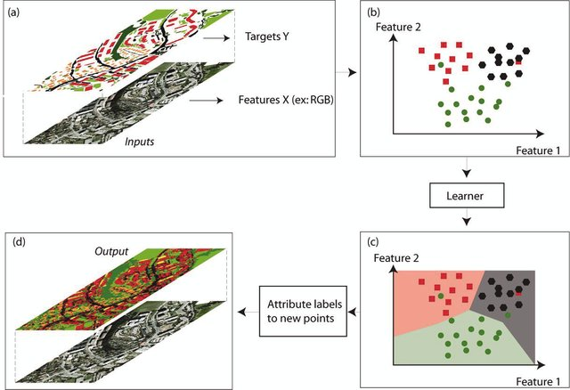

## Most popular Supervised learning Algorithms

Logistic Regression

Logistic Regression is used to estimate discrete values (usually binary values like 0/1) from a set of independent variables. It helps predict the probability of an event by fitting data to a logit function. It is also called logit regression.

Decision Tree

Decision Tree algorithm in machine learning is one of the most popular algorithm in use today; this is a supervised learning algorithm that is used for classifying problems. It works well classifying for both categorical and continuous dependent variables. In this algorithm, we split the population into two or more homogeneous sets based on the most significant attributes/ independent variables.

SVM (Support Vector Machine) Algorithm

SVM algorithm is a method of classification algorithm in which you plot raw data as points in an n-dimensional space (where n is the number of features you have). The value of each feature is then tied to a particular coordinate, making it easy to classify the data. Lines called classifiers can be used to split the data and plot them on a graph.

Naive Bayes Algorithm

A Naive Bayes classifier assumes that the presence of a particular feature in a class is unrelated to the presence of any other feature. Even if these features are related to each other, a Naive Bayes classifier would consider all of these properties independently when calculating the probability of a particular outcome. A Naive Bayesian model is easy to build and useful for massive datasets. It's simple and is known to outperform even highly sophisticated classification methods.

KNN (K- Nearest Neighbors) Algorithm

This algorithm can be applied to both classification and regression problems. Apparently, within the Data Science industry, it's more widely used to solve classification problems. It’s a simple algorithm that stores all available cases and classifies any new cases by taking a majority vote of its k neighbors. The case is then assigned to the class with which it has the most in common. A distance function performs this measurement. KNN can be easily understood by comparing it to real life. For example, if you want information about a person, it makes sense to talk to his or her friends and colleagues!

Random Forest

A collective of decision trees is called a Random Forest. To classify a new object based on its attributes, each tree is classified, and the tree “votes” for that class. The forest chooses the classification having the most votes (over all the trees in the forest).

Gradient Boosting Algorithm and AdaBoosting Algorithm

These are boosting algorithms used when massive loads of data have to be handled to make predictions with high accuracy. Boosting is an ensemble learning algorithm that combines the predictive power of several base estimators to improve robustness. In short, it combines multiple weak or average predictors to build a strong predictor. These boosting algorithms always work well in data science competitions like Kaggle, AV Hackathon, CrowdAnalytix. These are the most preferred machine learning algorithms today. Use them, along with Python and R Codes, to achieve accurate outcomes.

Artificial Neural Networks

An artificial neural network (ANN) comprises ‘units’ arranged in a series of layers, each of which connects to layers on either side. ANNs are inspired by biological systems, such as the brain, and how they process information. ANNs are essentially a large number of interconnected processing elements, working in unison to solve specific problems. ANNs also learn by example and through experience, and they are extremely useful for modelling non-linear relationships in high-dimensional data or where the relationship amongst the input variables is difficult to understand.

As an example, Let's use GEE to download a Sentinel 2 image from the year 2020 and its respective LULC map. From this data we train a classifier and predict the LULC map of the year 2021 from an image of that year.

First, let's install and import the necessary packages. After that we will authenticate Drive and GEE.

```python
!pip install rasterio
```

```
     |████████████████████████████████| 19.3 MB 61.7 MB/s
     |████████████████████████████████| 994 kB 6.8 MB/s
     |████████████████████████████████| 6.6 MB 24.2 MB/s
     |████████████████████████████████| 15.4 MB 37 kB/s
```

```python
import ee
ee.Authenticate()
ee.Initialize(project='my-project-1527255156007')
```

```python
from google.colab import drive
drive.mount('/content/drive')
```

```python
import folium
from folium import plugins
from IPython.display import Image
import rasterio
import numpy as np
from matplotlib import pyplot as plt
import cv2
from matplotlib import cm
import pandas as pd
import seaborn as sns
import json
from rasterio.mask import mask
from skimage.feature import graycomatrix, graycoprops
```

We defined our study area and the date of the images:

```python
AOI = ee.Geometry.Polygon(
        [[[5.516689929215324, 52.79285519485472],
          [5.516689929215324, 52.51126453687936],
          [6.181362780777824, 52.51126453687936],
          [6.181362780777824, 52.79285519485472]]])
```

```python
startDateviz_before = ee.Date.fromYMD(2020,3,1);
endDateviz_before = ee.Date.fromYMD(2020,10,31);
startDateviz_after = ee.Date.fromYMD(2021,1,1);
endDateviz_after = ee.Date.fromYMD(2021,7,31);

collectionviz_before = ee.ImageCollection("COPERNICUS/S2_HARMONIZED").filterDate(startDateviz_before,endDateviz_before).filterBounds(AOI).filterMetadata('CLOUDY_PIXEL_PERCENTAGE', 'less_than', 1);
collectionviz_after = ee.ImageCollection("COPERNICUS/S2_HARMONIZED").filterDate(startDateviz_after,endDateviz_after).filterBounds(AOI).filterMetadata('CLOUDY_PIXEL_PERCENTAGE', 'less_than', 1);
```

We selected the 2020 LULC dataset:

```python
esri_lulc10 = ee.ImageCollection("projects/sat-io/open-datasets/landcover/ESRI_Global-LULC_10m");
```

So we can use Folium to plot the data:

```python
colors =  ["#1A5BAB","#358221","#A7D282","#87D19E","#FFDB5C","#EECFA8","#ED022A","#EDE9E4","#F2FAFF","#C8C8C8"]
```

```python
esri_lulc10 = esri_lulc10.mosaic().clip(AOI).rename('LULC')
vis_params_lulc = {'min': 1, 'max': 10, 'palette':colors}
```

```python
S2_before = collectionviz_before.median().clip(AOI).divide(10000)
S2_after = collectionviz_after.median().clip(AOI).divide(10000)

vis_params = {'min': 0, 'max': 0.4, 'bands': ['B4', 'B3','B2']}
```

```python
basemaps = {
    'Google Satellite': folium.TileLayer(
        tiles = 'https://mt1.google.com/vt/lyrs=s&x={x}&y={y}&z={z}',
        attr = 'Google',
        name = 'Google Satellite',
        overlay = True,
        control = True
    ),
    'Google Terrain': folium.TileLayer(
        tiles = 'https://mt1.google.com/vt/lyrs=p&x={x}&y={y}&z={z}',
        attr = 'Google',
        name = 'Google Terrain',
        overlay = True,
        control = True
    )}
```

```python
def add_ee_layer(self, ee_object, vis_params, name):

    try:
        # display ee.Image()
        if isinstance(ee_object, ee.image.Image):
            map_id_dict = ee.Image(ee_object).getMapId(vis_params)
            folium.raster_layers.TileLayer(
            tiles = map_id_dict['tile_fetcher'].url_format,
            attr = 'Google Earth Engine',
            name = name,
            overlay = True,
            control = True
            ).add_to(self)
        # display ee.ImageCollection()
        elif isinstance(ee_object, ee.imagecollection.ImageCollection):
            ee_object_new = ee_object.mosaic()
            map_id_dict = ee.Image(ee_object_new).getMapId(vis_params)
            folium.raster_layers.TileLayer(
            tiles = map_id_dict['tile_fetcher'].url_format,
            attr = 'Google Earth Engine',
            name = name,
            overlay = True,
            control = True
            ).add_to(self)
        # display ee.Geometry()
        elif isinstance(ee_object, ee.geometry.Geometry):
            folium.GeoJson(
            data = ee_object.getInfo(),
            name = name,
            overlay = True,
            control = True
        ).add_to(self)
        # display ee.FeatureCollection()
        elif isinstance(ee_object, ee.featurecollection.FeatureCollection):
            ee_object_new = ee.Image().paint(ee_object, 0, 2)
            map_id_dict = ee.Image(ee_object_new).getMapId(vis_params)
            folium.raster_layers.TileLayer(
            tiles = map_id_dict['tile_fetcher'].url_format,
            attr = 'Google Earth Engine',
            name = name,
            overlay = True,
            control = True
        ).add_to(self)

    except:
        print("Could not display {}".format(name))

# Add EE drawing method to folium.
folium.Map.add_ee_layer = add_ee_layer
```

```python
my_map = folium.Map(location=AOI.centroid().coordinates().reverse().getInfo(), zoom_start=11)

# Add custom basemaps
basemaps['Google Terrain'].add_to(my_map)

# Add the elevation model to the map object.
my_map.add_ee_layer(esri_lulc10, vis_params_lulc, 'Netherlands LULC 2020')
my_map.add_ee_layer(S2_before, vis_params, 'Netherlands 2020')
my_map.add_ee_layer(S2_after, vis_params, 'Netherlands 2021')
my_map.add_child(folium.LayerControl())

# Display the map.
display(my_map)
```

Make this Notebook Trusted to load map: File -> Trust Notebook

[interactive chart not shown]

Now let's download this data to Drive:

```python
S2_before = S2_before.addBands(esri_lulc10)
S2_before = S2_before.toFloat()
S2_after = S2_after.toFloat()
```

```python
image_before = S2_before.select(['B2','B3','B4','B5','B6','B7','B8','B8A','B11','B12','LULC']).reproject('EPSG:4326', None, 20)
image_after = S2_after.select(['B2','B3','B4','B5','B6','B7','B8','B8A','B11','B12']).reproject('EPSG:4326', None, 20)
```

```python
task = ee.batch.Export.image.toDrive(image=image_before,
                                         crs='EPSG:4326',
                                         scale=20,
                                         fileFormat='GeoTIFF',
                                         description='Netherlands_2020' ,
                                         maxPixels=1e13,
                                         folder='Datasets',
                                         region= AOI)
```

```python
task.start()
```

```python
task2 = ee.batch.Export.image.toDrive(image=image_after,
                                         crs='EPSG:4326',
                                         scale=20,
                                         fileFormat='GeoTIFF',
                                         description='Netherlands_2021' ,
                                         maxPixels=1e13,
                                         folder='Datasets',
                                         region= AOI)
```

```python
task2.start()
```

We are going to use the rasterio to import the data:

```python
path_before = '/content/drive/MyDrive/Datasets_CV/Netherlands_2020.tif'
path_after= '/content/drive/MyDrive/Datasets_CV/Netherlands_2021.tif'
```

```python
with rasterio.open(path_before) as src:
    im_before = src.read()
```

```python
with rasterio.open(path_after) as src:
    im_after = src.read()
    out_meta = src.meta.copy()
```

```python
im_before = im_before.transpose([1,2,0])
im_after = im_after.transpose([1,2,0])
```

The 2020 image contains the 10 selected Sentinel 2 bands plus LULC, and the 2021 image contains only the 10 Sentinel 2 bands:

```python
im_before.shape
```

```
(1571, 3701, 11)
```

```python
im_after.shape
```

```
(1571, 3701, 10)
```

As the 2020 data will be used for model training, let's call the spectral values of X and the LULC of Y.

```python
X = im_before[:,:,0:-1]
Y = im_before[:,:,-1]
```

Let's use the nan_to_num function to transform possible NaN values into zeros:

```python
X = np.nan_to_num(X)
Y = np.nan_to_num(Y)
```

We will also flatten the two-dimensional image (HxW) to a single-dimensional vector.

```python
flatten_X = X.reshape(X.shape[0]*X.shape[1],X.shape[2])
```

```python
flatten_Y = Y.flatten()
```

Here, we will delete the 0 values in both the spectral data matrix and the labels vector:

```python
flatten_X = np.delete(flatten_X, np.where(flatten_Y == 0), axis = 0)
```

```python
flatten_Y = np.delete(flatten_Y, np.where(flatten_Y == 0))
```

The variable X contains a matrix representing each pixel by each spectral band.

```python
flatten_X.shape
```

```
(5804108, 10)
```

The Y variable represents each pixel of the LULC target map:

```python
flatten_Y.shape
```

```
(5804108,)
```

Let's import some Sklearn functions:

```python
from sklearn.model_selection import train_test_split
from sklearn.ensemble import RandomForestClassifier
from sklearn.metrics import classification_report
from sklearn.metrics import cohen_kappa_score
from sklearn.metrics import confusion_matrix
```

Now we'll split the data into training data and testing data:

```python
X_train, X_test, Y_train, Y_test = train_test_split(flatten_X, flatten_Y, test_size = 0.3, random_state = 42)
```

To reduce memory usage, we can delete some variables that we will no longer use:

```python
del X,Y,flatten_X,flatten_Y
```

It's time to create the classifier instance. Let's use Random Forest, with 50 estimators:

```python
clf=RandomForestClassifier(n_estimators=50, n_jobs=8, verbose=3)
```

And then we can fit the classifier with training data:

```python
clf.fit(X_train,Y_train)
```

```
[Parallel(n_jobs=8)]: Using backend ThreadingBackend with 8 concurrent workers.
```

[output not shown]

```
[Parallel(n_jobs=8)]: Done  16 tasks      | elapsed:  7.0min
```

[output not shown]

```
[Parallel(n_jobs=8)]: Done  50 out of  50 | elapsed: 18.2min finished
```

```
RandomForestClassifier(bootstrap=True, ccp_alpha=0.0, class_weight=None,
                       criterion='gini', max_depth=None, max_features='auto',
                       max_leaf_nodes=None, max_samples=None,
                       min_impurity_decrease=0.0, min_impurity_split=None,
                       min_samples_leaf=1, min_samples_split=2,
                       min_weight_fraction_leaf=0.0, n_estimators=50, n_jobs=8,
                       oob_score=False, random_state=None, verbose=3,
                       warm_start=False)
```

Due to the amount of data, it is possible that the training may take a little longer. When finished, we can perform test data prediction:

```python
y_pred=clf.predict(X_test)
```

```
[Parallel(n_jobs=8)]: Using backend ThreadingBackend with 8 concurrent workers.
[Parallel(n_jobs=8)]: Done  16 tasks      | elapsed:   19.4s
[Parallel(n_jobs=8)]: Done  50 out of  50 | elapsed:   51.7s finished
```

Let's get the accuracy values from the training data and from the testing data:

```python
print("Accuracy on training set: {:.2f}".format(clf.score(X_train, Y_train)))
print("Accuracy on test set: {:.2f}".format(clf.score(X_test, Y_test)))
```

```
[Parallel(n_jobs=8)]: Using backend ThreadingBackend with 8 concurrent workers.
[Parallel(n_jobs=8)]: Done  16 tasks      | elapsed:   37.2s
[Parallel(n_jobs=8)]: Done  50 out of  50 | elapsed:  1.8min finished
```

```
Accuracy on training set: 1.00
```

```
[Parallel(n_jobs=8)]: Using backend ThreadingBackend with 8 concurrent workers.
[Parallel(n_jobs=8)]: Done  16 tasks      | elapsed:   15.7s
[Parallel(n_jobs=8)]: Done  50 out of  50 | elapsed:   46.4s finished
```

```
Accuracy on test set: 0.88
```

We can also use classification_report to get other metrics:

```python
print(classification_report(Y_test, y_pred))
```

```
              precision    recall  f1-score   support

         1.0       0.96      0.96      0.96    307473
         2.0       0.69      0.74      0.72     72100
         3.0       0.59      0.17      0.27     63589
         4.0       0.48      0.42      0.45     32832
         5.0       0.89      0.96      0.92   1073949
         6.0       0.48      0.18      0.26     13990
         7.0       0.80      0.65      0.72    177055
         8.0       0.94      0.18      0.31       245
        10.0       0.00      0.00      0.00         0

    accuracy                           0.88   1741233
   macro avg       0.65      0.48      0.51   1741233
weighted avg       0.86      0.88      0.86   1741233
```

One of the main ways to get an overview of the result of the test data prediction is through the confusion matrix.

A Confusion matrix is an N x N matrix used for evaluating the performance of a classification model, where N is the number of target classes. The matrix compares the actual target values with those predicted by the machine learning model. This gives us a holistic view of how well our classification model is performing and what kinds of errors it is making.

```python
c_matrix = confusion_matrix(Y_test, y_pred)
```

```python
names = [ "Water","Trees","Grass","Flooded Vegetation","Crops","Scrub/Shrub","Built Area","Bare Ground","Clouds"]
```

Let's use matplotlib and seaborn to plot the confusion matrix:

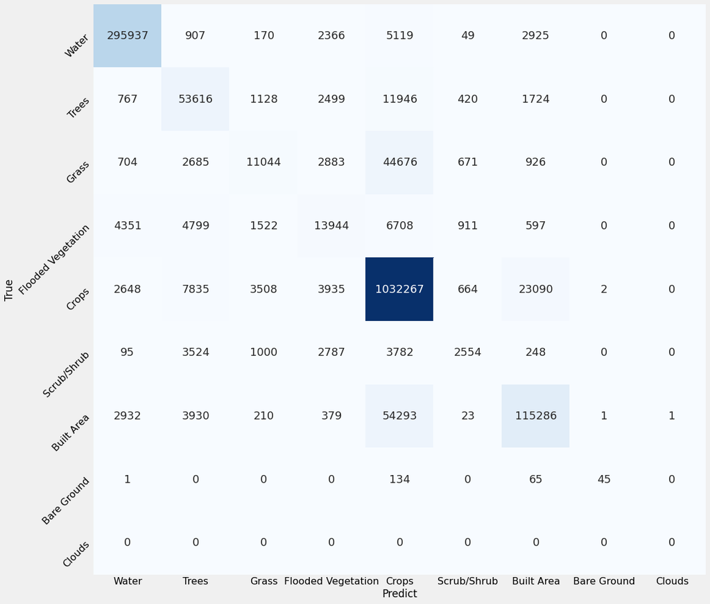

```python
r1 = pd.DataFrame(data=c_matrix, index= names, columns=names)
fig, ax = plt.subplots(figsize=(16,16))
ax = sns.heatmap(r1, annot=True, annot_kws={"size": 18},fmt='d',cmap="Blues", cbar = False)
#for t in ax.texts: t.set_text(t.get_text() + " %")
ax.tick_params(labelsize=16)
ax.set_yticklabels(names, rotation=45)
ax.set_ylabel('True')
ax.set_xlabel('Predict')
```

After analyzing the metrics, we have to decide if this model is good enough or if we need to improve it. With the model in hand, it is time to predict the LULC map for the 2021 data:

First we convert the NaN values to zeros.

```python
Predict_img = np.nan_to_num(im_after)
```

We flatten the image, resulting in a vector of pixels for each spectral band:

```python
Predict_img = Predict_img.reshape(im_after.shape[0]*im_after.shape[1],im_after.shape[2])
```

And we use our trained model to make the inference:

```python
array_pred=clf.predict(Predict_img)
```

```
[Parallel(n_jobs=8)]: Using backend ThreadingBackend with 8 concurrent workers.
[Parallel(n_jobs=8)]: Done  16 tasks      | elapsed:   32.4s
[Parallel(n_jobs=8)]: Done  50 out of  50 | elapsed:  1.5min finished
```

Now we add 0 to values that were no-data in the original image for the resulting LULC:

```python
array_pred = np.where(Predict_img[:,0] == 0,0,array_pred)
```

Let's convert data to integers:

```python
array_pred = array_pred.astype('uint8')
```

Finally we return the original shape of the image:

```python
array_pred = array_pred.reshape(im_after.shape[0],im_after.shape[1])
```

We can plot the resulting image with some chosen colormap:

```
(-0.5, 3700.5, 1570.5, -0.5)
```

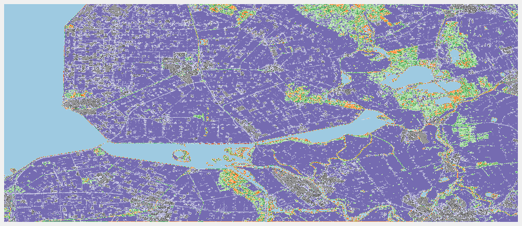

```python
plt.figure(figsize=[14,10])
plt.imshow(array_pred,cmap='tab20c')
plt.axis('off')
```

If necessary, you can export the image in a .tiff file:

```python
export_image = array_pred[np.newaxis,:,:]
```

```python
out_meta.update({"driver": "GTiff",
                  "height": export_image.shape[1],
                  "width": export_image.shape[2],
                  "compress":'lzw',
                  "count":1
                  })
```

```python
 with rasterio.open('/content/Netherlands_2021_LULC.tif', "w", **out_meta) as dest:
     dest.write(export_image)
```

# OBIA – Object-Based Image Analysis (GEOBIA) Classification

Object – based image analysis (OBIA), a technique used to analyze digital imagery, was developed relatively recently compared to traditional pixel-based image analysis (Burnett and Blaschke 2003). While pixel-based image analysis is based on the information in each pixel, object-based image analysis is based on information from a set of similar pixels called objects or image objects. More specifically, image objects are groups of pixels that are similar to one another based on a measure of spectral properties (i.e., color), size, shape, and texture, as well as context from a neighborhood surrounding the pixels.

OBIA does not analyze a single pixel, but rather a homogeneous group of pixels — image objects. An object, contrary to a pixel, provides richer information, including spectrum, texture, shape, spatial relationships, and ancillary spatial data. In turn, spatial context can be exploited to emulate a human analyst, who intuitively identifies various objects in an image, rather than individual pixels, by considering various properties, such as size, texture, shape, and the spatial arrangements of these objects to understand the semantics. The fundamental objective of OBIA, therefore, is to use segmentation to reduce complexity of image data, and to use the extracted image objects and their corresponding attributes (features) to develop strategies for thematic classification. With OBIA, images are segmented to make image objects from various groups of pixels to represent meaningful objects in the scene. Ontologically, this provides more accurate and reliable identification and extraction of real-world features and at more appropriate scales. Moreover, it provides the opportunity to divide map data into homogenous objects of various spatial scales.

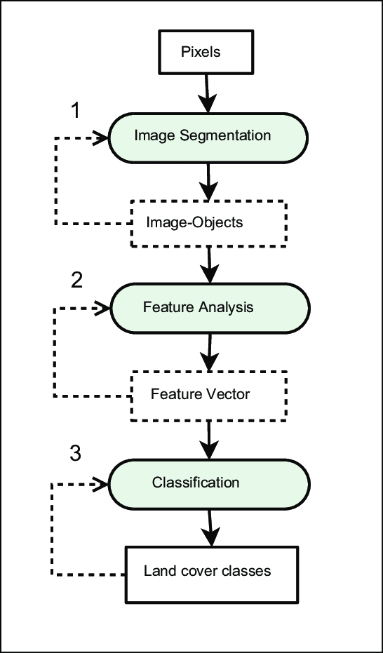

Here in this example, we are going to use the 2020 Sentinel 2 image of our study area to perform the OBIA classification. First we will segment the image, collect sample points from predefined classes, extract some features from the objects, train the classifier and finally perform the inference for all image segments.

## Import the Image

We start by importing the image and generating an RGB image so that we can plot with matplotlib:

```python
path_before = '/content/drive/MyDrive/Datasets_CV/Netherlands_2020.tif'
```

```python
src = rasterio.open(path_before)
im_before = src.read()
```

```python
im_before = im_before.transpose([1,2,0])
```

```python
red = im_before[:,:,2]
green = im_before[:,:,1]
blue = im_before[:,:,0]
```

```
(-0.5, 3700.5, 1570.5, -0.5)
```

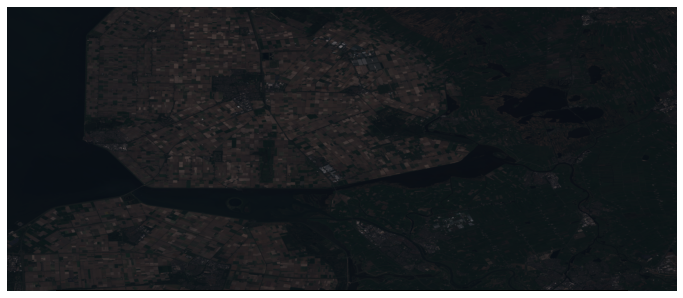

```python
rgb = np.dstack((red, green, blue))
plt.figure(figsize=[12,12])
plt.imshow(rgb)
plt.axis('off')
```

## Segment the Image

As we saw in previous lessons, we are going to perform the image segmentation. First we convert the RGB image to float:

```python
from skimage.segmentation import felzenszwalb, slic, quickshift, watershed
from skimage.segmentation import mark_boundaries
from skimage.util import img_as_float
```

```python
img = img_as_float(rgb)
```

Now let's remove possible NaN values:

```python
img = np.nan_to_num(img)
```

And then we use the quickshift algorithm to segment the image.

```python
segments_quick = quickshift(img, kernel_size=3, max_dist=50, ratio=0.9)
```

```
(-0.5, 3700.5, 1570.5, -0.5)
```

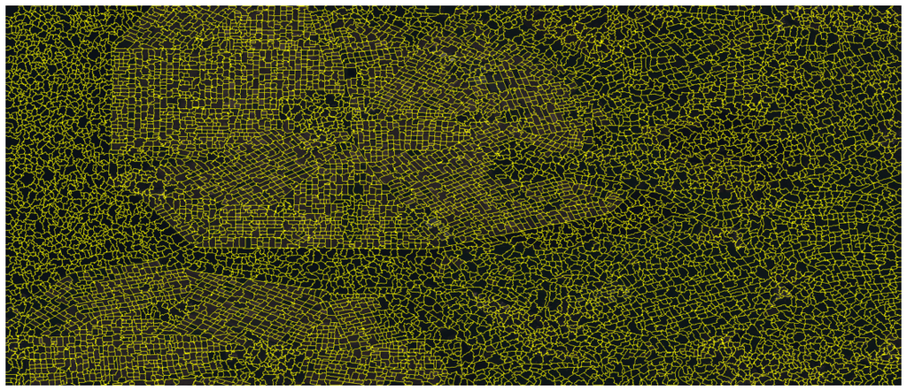

```python
plt.figure(figsize=[20,14])
plt.imshow(mark_boundaries(img, segments_quick))
plt.axis('off')
```

After generating the boundaries of each segment, we will transform these objects into georeferenced polygons and create a GeoDataFrame with the help of the Shapely and Geopandas libraries:

```python
segments_quick = segments_quick.astype('uint16')
```

```python
from rasterio import features
from shapely.geometry import shape
import geopandas as gpd
import shapely
```

```python
find_shapes = features.shapes(segments_quick, transform=src.transform)
```

```python
polygons = [shapely.geometry.Polygon(shape[0]["coordinates"][0]) for shape in find_shapes]
```

```python
crs = {'init': 'epsg:4326'}
Poly_gdf = gpd.GeoDataFrame(crs=crs, geometry=polygons)
```

Here we can see our GeoDataFrame:

```python
Poly_gdf
```

|  | geometry |
| --- | --- |
| 0 | POLYGON ((5.89474 52.79327, 5.89474 52.79309, ... |
| 1 | POLYGON ((5.91666 52.79327, 5.91666 52.79309, ... |
| 2 | POLYGON ((5.96966 52.79327, 5.96966 52.79309, ... |
| 3 | POLYGON ((6.10567 52.79309, 6.10567 52.79291, ... |
| 4 | POLYGON ((5.90337 52.79273, 5.90337 52.79255, ... |
| ... | ... |
| 15761 | POLYGON ((6.12004 52.51533, 6.12004 52.51461, ... |
| 15762 | POLYGON ((6.13244 52.51767, 6.13244 52.51731, ... |
| 15763 | POLYGON ((6.15166 52.51857, 6.15166 52.51839, ... |
| 15764 | POLYGON ((6.16640 52.51893, 6.16640 52.51875, ... |
| 15765 | POLYGON ((6.17915 52.51695, 6.17915 52.51677, ... |

15766 rows × 1 columns

We were also able to plot the boundaries of each polygon:

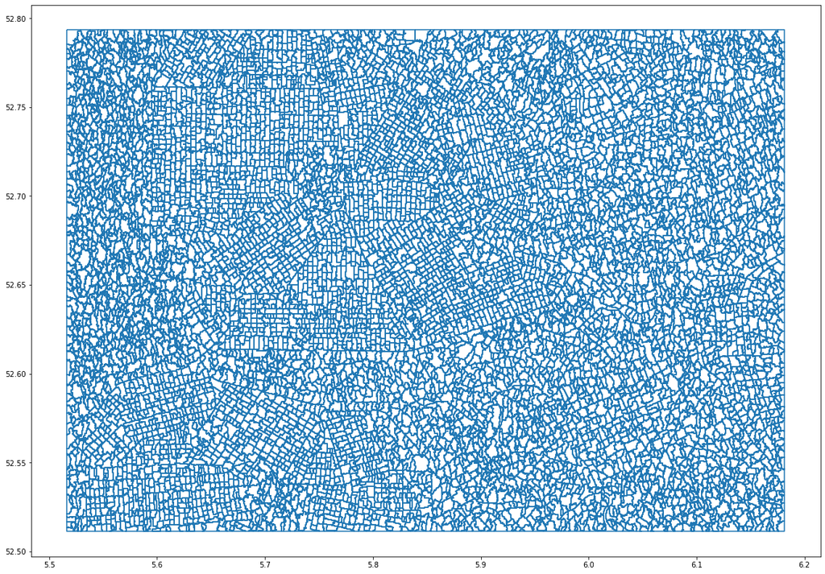

```python
Poly_gdf.boundary.plot(figsize=(20,14))
```

## Import the Samples

Now let's open the shapefile with the collected points representing the classes: Water, Trees, Grass, Crops and Builts:

```python
samples = gpd.read_file('/content/drive/MyDrive/Datasets_CV/samples/Samples.shp')
```

The classes received values from 1 to 5:

```python
samples
```

|  | class | geometry |
| --- | --- | --- |
| 0 | 1 | POINT (5.59104 52.63066) |
| 1 | 1 | POINT (5.57628 52.67148) |
| 2 | 1 | POINT (5.56547 52.62878) |
| 3 | 1 | POINT (5.53530 52.59357) |
| 4 | 1 | POINT (5.53427 52.65651) |
| ... | ... | ... |
| 194 | 5 | POINT (6.11477 52.51564) |
| 195 | 5 | POINT (6.09777 52.51888) |
| 196 | 5 | POINT (6.09417 52.51303) |
| 197 | 5 | POINT (6.13605 52.52358) |
| 198 | 5 | POINT (6.16524 52.53371) |

199 rows × 2 columns

## Extract the Samples Segments

As our image was divided into segments, let's find the segments that intersect the samples points collected:

```python
poly_geometry = []
poly_id = []
poly_class = []
for p, point in samples.iterrows():
  for i, poly in Poly_gdf.iterrows():
    if (point['geometry'].within(poly['geometry'])):
      print(p,i)
      poly_geometry.append(poly['geometry'])
      poly_id.append(i)
      poly_class.append(point['class'])
```

```
0 9545
1 7213
2 9548
3 11315
4 8468
5 10599
6 10839
7 4064
8 3163
9 10790
10 9711
11 9253
12 8533
13 5736
14 5059
```

[output cut: 184 more lines]

So we can create a dataframe containing the segment id and the class and then join it with the polygon geometry in a new GeoDataFrame:

```python
id_class = np.stack((poly_id,poly_class), axis=1)
```

```python
id_class.shape
```

```
(199, 2)
```

```python
df = pd.DataFrame(id_class,columns=['id','class'])
```

```python
dataset = gpd.GeoDataFrame(df, geometry=poly_geometry)
```

After that, let's remove the duplicate segments:

```python
dataset = dataset[~dataset['id'].duplicated()]
```

```python
dataset
```

|  | id | class | geometry |
| --- | --- | --- | --- |
| 0 | 9545 | 1 | POLYGON ((5.58932 52.63966, 5.58932 52.63948, ... |
| 1 | 7213 | 1 | POLYGON ((5.58087 52.67936, 5.58087 52.67918, ... |
| 2 | 9548 | 1 | POLYGON ((5.56955 52.63607, 5.56955 52.63589, ... |
| 3 | 11315 | 1 | POLYGON ((5.53129 52.59564, 5.53129 52.59546, ... |
| 4 | 8468 | 1 | POLYGON ((5.53003 52.65960, 5.53003 52.65942, ... |
| ... | ... | ... | ... |
| 194 | 15520 | 5 | POLYGON ((6.11699 52.51857, 6.11699 52.51803, ... |
| 195 | 15358 | 5 | POLYGON ((6.09758 52.52090, 6.09758 52.52054, ... |
| 196 | 15757 | 5 | POLYGON ((6.08788 52.51605, 6.08788 52.51587, ... |
| 197 | 15281 | 5 | POLYGON ((6.14034 52.52431, 6.14034 52.52396, ... |
| 198 | 14590 | 5 | POLYGON ((6.16765 52.53869, 6.16765 52.53851, ... |

187 rows × 3 columns

## Extract features from the Training Image

Let's now extract the image features from each selected polygon. Here in this example, we're just going to get the mean of each spectral band. We'll also select the GLCM texture features.

```python
json_dataset = json.loads(dataset.to_json())['features']
```

```python
X = []
Y = []
for i in range(len(json_dataset)):
  coords = json_dataset[i]['geometry']
  out_image, out_transform = rasterio.mask.mask(src, [coords], crop=True)
  out_image = out_image.transpose([1,2,0])
  out_image = np.nan_to_num(out_image)

  B2_mean = out_image[:,:,0][np.nonzero(out_image[:,:,0])].mean()
  B3_mean = out_image[:,:,1][np.nonzero(out_image[:,:,1])].mean()
  B4_mean = out_image[:,:,2][np.nonzero(out_image[:,:,2])].mean()
  B5_mean = out_image[:,:,3][np.nonzero(out_image[:,:,3])].mean()
  B6_mean = out_image[:,:,4][np.nonzero(out_image[:,:,4])].mean()
  B7_mean = out_image[:,:,5][np.nonzero(out_image[:,:,5])].mean()
  B8_mean = out_image[:,:,6][np.nonzero(out_image[:,:,6])].mean()
  B8A_mean = out_image[:,:,7][np.nonzero(out_image[:,:,7])].mean()
  B11_mean = out_image[:,:,8][np.nonzero(out_image[:,:,8])].mean()
  B12_mean = out_image[:,:,9][np.nonzero(out_image[:,:,9])].mean()

  norm_image = cv2.normalize(out_image[:,:,8], None, alpha = 0, beta = 255, norm_type = cv2.NORM_MINMAX, dtype = cv2.CV_8U)
  distances = [1]
  angles = [ np.pi/2]
  glcm = graycomatrix(norm_image,
                                distances=distances,
                                angles=angles,
                                symmetric=True,
                                normed=True,
                                levels=256)
  contrast = np.array(graycoprops(glcm, 'contrast')).ravel()[0]
  energy = np.array(graycoprops(glcm, 'energy')).ravel()[0]
  homogeneity = np.array(graycoprops(glcm, 'homogeneity')).ravel()[0]
  correlation = np.array(graycoprops(glcm, 'correlation')).ravel()[0]
  dissimilarity = np.array(graycoprops(glcm, 'dissimilarity')).ravel()[0]
  ASM = np.array(graycoprops(glcm,'ASM')).ravel()[0]

  X.append([B2_mean,B3_mean,B4_mean,B5_mean,B6_mean,B7_mean,B8_mean,B8A_mean,B11_mean,B12_mean,contrast,energy,homogeneity,correlation,dissimilarity,ASM])
  Y.append(json_dataset[i]['properties']['class'])
```

So we have our dataset with the features for each selected polygon and the target:

```python
X = np.array(X)
Y = np.array(Y)
```

## Training the Model

For ML model training, let's perform the same way we did for pixel classification:

```python
X_train, X_test, Y_train, Y_test = train_test_split(X, Y, test_size = 0.3, random_state = 42)
```

```python
clf=RandomForestClassifier(n_estimators=50, n_jobs=8, verbose=3)
```

```python
clf.fit(X_train,Y_train)
```

```
[Parallel(n_jobs=8)]: Using backend ThreadingBackend with 8 concurrent workers.
[Parallel(n_jobs=8)]: Done  16 tasks      | elapsed:    0.1s
[Parallel(n_jobs=8)]: Done  50 out of  50 | elapsed:    0.1s finished
```

[output not shown]

```
RandomForestClassifier(bootstrap=True, ccp_alpha=0.0, class_weight=None,
                       criterion='gini', max_depth=None, max_features='auto',
                       max_leaf_nodes=None, max_samples=None,
                       min_impurity_decrease=0.0, min_impurity_split=None,
                       min_samples_leaf=1, min_samples_split=2,
                       min_weight_fraction_leaf=0.0, n_estimators=50, n_jobs=8,
                       oob_score=False, random_state=None, verbose=3,
                       warm_start=False)
```

```python
y_pred=clf.predict(X_test)
```

```
[Parallel(n_jobs=8)]: Using backend ThreadingBackend with 8 concurrent workers.
[Parallel(n_jobs=8)]: Done  16 tasks      | elapsed:    0.0s
[Parallel(n_jobs=8)]: Done  50 out of  50 | elapsed:    0.0s finished
```

```python
print("Accuracy on training set: {:.2f}".format(clf.score(X_train, Y_train)))
print("Accuracy on test set: {:.2f}".format(clf.score(X_test, Y_test)))
```

```
[Parallel(n_jobs=8)]: Using backend ThreadingBackend with 8 concurrent workers.
[Parallel(n_jobs=8)]: Done  16 tasks      | elapsed:    0.0s
[Parallel(n_jobs=8)]: Done  50 out of  50 | elapsed:    0.0s finished
[Parallel(n_jobs=8)]: Using backend ThreadingBackend with 8 concurrent workers.
[Parallel(n_jobs=8)]: Done  16 tasks      | elapsed:    0.0s
[Parallel(n_jobs=8)]: Done  50 out of  50 | elapsed:    0.0s finished
```

```
Accuracy on training set: 1.00
Accuracy on test set: 0.75
```

```python
print(classification_report(Y_test, y_pred))
```

```
              precision    recall  f1-score   support

           1       0.78      0.88      0.82        16
           2       0.78      0.88      0.82         8
           3       0.50      0.33      0.40         6
           4       0.73      0.92      0.81        12
           5       0.82      0.60      0.69        15

    accuracy                           0.75        57
   macro avg       0.72      0.72      0.71        57
weighted avg       0.75      0.75      0.74        57
```

## Predict Full Image

The last step is to perform the inference of all image segments using the trained model. Let's extract the features, but now for all segments:

```python
json_dataset_full = json.loads(Poly_gdf.to_json())['features']
```

```python
X_pred = []
id_pred = []
for i in range(len(json_dataset_full)):
  coords = json_dataset_full[i]['geometry']
  out_image, out_transform = rasterio.mask.mask(src, [coords], crop=True)
  out_image = out_image.transpose([1,2,0])
  out_image = np.nan_to_num(out_image)

  B2_mean = out_image[:,:,0][np.nonzero(out_image[:,:,0])].mean()
  B3_mean = out_image[:,:,1][np.nonzero(out_image[:,:,1])].mean()
  B4_mean = out_image[:,:,2][np.nonzero(out_image[:,:,2])].mean()
  B5_mean = out_image[:,:,3][np.nonzero(out_image[:,:,3])].mean()
  B6_mean = out_image[:,:,4][np.nonzero(out_image[:,:,4])].mean()
  B7_mean = out_image[:,:,5][np.nonzero(out_image[:,:,5])].mean()
  B8_mean = out_image[:,:,6][np.nonzero(out_image[:,:,6])].mean()
  B8A_mean = out_image[:,:,7][np.nonzero(out_image[:,:,7])].mean()
  B11_mean = out_image[:,:,8][np.nonzero(out_image[:,:,8])].mean()
  B12_mean = out_image[:,:,9][np.nonzero(out_image[:,:,9])].mean()

  norm_image = cv2.normalize(out_image[:,:,8], None, alpha = 0, beta = 255, norm_type = cv2.NORM_MINMAX, dtype = cv2.CV_8U)
  distances = [1]
  angles = [ np.pi/2]
  glcm = graycomatrix(norm_image,
                                distances=distances,
                                angles=angles,
                                symmetric=True,
                                normed=True,
                                levels=256)
  contrast = np.array(graycoprops(glcm, 'contrast')).ravel()[0]
  energy = np.array(graycoprops(glcm, 'energy')).ravel()[0]
  homogeneity = np.array(graycoprops(glcm, 'homogeneity')).ravel()[0]
  correlation = np.array(graycoprops(glcm, 'correlation')).ravel()[0]
  dissimilarity = np.array(graycoprops(glcm, 'dissimilarity')).ravel()[0]
  ASM = np.array(graycoprops(glcm,'ASM')).ravel()[0]

  X_pred.append([B2_mean,B3_mean,B4_mean,B5_mean,B6_mean,B7_mean,B8_mean,B8A_mean,B11_mean,B12_mean,contrast,energy,homogeneity,correlation,dissimilarity,ASM])
  id_pred.append(json_dataset_full[i]['id'])
```

```python
X_pred = np.array(X_pred)
ID = np.array(id_pred)
```

```python
X_pred = np.nan_to_num(X_pred)
```

```python
img_pred=clf.predict(X_pred)
```

```
[Parallel(n_jobs=8)]: Using backend ThreadingBackend with 8 concurrent workers.
[Parallel(n_jobs=8)]: Done  16 tasks      | elapsed:    0.0s
[Parallel(n_jobs=8)]: Done  50 out of  50 | elapsed:    0.1s finished
```

```python
ID = ID.astype('uint16')
```

After performing the inference, let's set the predicted class for the image segments:

```python
Poly_gdf['class'] = img_pred
```

We also map the class names according to the numbers used:

```python
names = { 1:'Water',
          2:'Trees',
          3:'Grass',
          4:'Crops',
          5:'Built'}
```

```python
Poly_gdf['class_name'] = Poly_gdf['class'].replace(names)
```

Let's plot the result of the classified image by adding a legend:

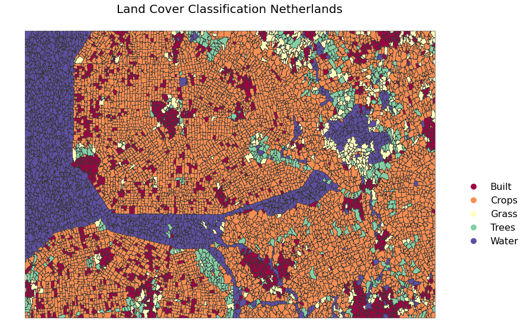

```python
fig, ax = plt.subplots(1, figsize=(14,8))
Poly_gdf.plot(column='class_name', categorical=True, cmap='Spectral', linewidth=.6, edgecolor='0.2',
         legend=True, legend_kwds={'bbox_to_anchor':(1, 0.5),'loc':'upper left','fontsize':16,'frameon':False}, ax=ax)
ax.axis('off')
ax.set_title('Land Cover Classification Netherlands',fontsize=20)
plt.tight_layout()
```

## Image Classification with HOG and SVM

Another task that can be performed with satellite images is image classification, where each image is classified and not just its pixels. Let's take for example this Kaggle Dataset which contains images of Ships and Non-Ships:

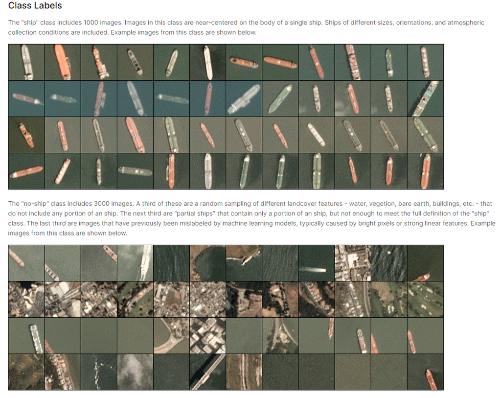

Let's start by importing some libraries that we'll use:

```python
import json
from skimage import color
from skimage.feature import hog
from sklearn import svm
```

Let's open the file containing the image data and their respective labels:

```python
path = open(r'/content/drive/MyDrive/Datasets_CV/Ship_Dataset/shipsnet.json')
ships_pahts = json.load(path)
path.close()
```

```python
ships_pahts.keys()
```

```
dict_keys(['data', 'labels', 'locations', 'scene_ids'])
```

Let's get the images, reshape them and plot an example:

```python
Image_dataset = np.array(ships_pahts['data']).astype('uint8')
```

```python
img_length = 80
Image_dataset = Image_dataset.reshape(-1,3,img_length,img_length).transpose([0,2,3,1])
```

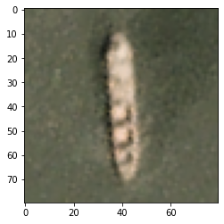

```python
plt.imshow(Image_dataset[500])
```

We will also get the labels:

```python
Y = np.array(ships_pahts['labels']).reshape(len(ships_pahts['labels']),1)
```

```python
np.unique(Y,return_counts=True)
```

```
(array([0, 1]), array([3000, 1000]))
```

As each image in our dataset contains a huge range of spectral values representing ships that don't follow a specific pattern, it would be useless to perform classification with these values. But as we saw in previous lessons, we can get some features like shapes present in the image, using the HOG.

First we convert the RGB image to grayscale:

```python
X_gray = [color.rgb2gray(i) for i in Image_dataset]
```

Then we create the dataset with the HOG of each image:

```python
hog_images = []
hog_features = []
for image in X_gray:
    fd,hog_image = hog(image, orientations=8, pixels_per_cell=(16,16),cells_per_block=(4, 4), visualize=True)
    hog_images.append(hog_image)
    hog_features.append(fd)
```

Let's plot an example:

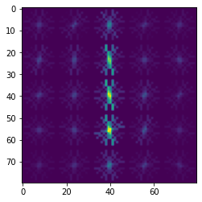

```python
plt.imshow(hog_images[500])
```

Now we can convert the HOG image into a feature vector and train an SVM to perform image classification:

```python
X = np.array(hog_images)
```

```python
X = X.reshape(X.shape[0],X.shape[1]*X.shape[2])
```

```python
X_train, X_test, Y_train, Y_test = train_test_split(X, Y, test_size = 0.3, random_state = 42)
```

```python
clf = svm.SVC()
```

```python
clf.fit(X_train,Y_train)
```

```
SVC(C=1.0, break_ties=False, cache_size=200, class_weight=None, coef0=0.0,
    decision_function_shape='ovr', degree=3, gamma='scale', kernel='rbf',
    max_iter=-1, probability=False, random_state=None, shrinking=True,
    tol=0.001, verbose=False)
```

```python
y_pred=clf.predict(X_test)
```

So we can check our model's evaluation metrics:

```python
print(classification_report(Y_test, y_pred))
```

```
              precision    recall  f1-score   support

           0       0.99      0.99      0.99       885
           1       0.98      0.97      0.98       315

    accuracy                           0.99      1200
   macro avg       0.99      0.98      0.98      1200
weighted avg       0.99      0.99      0.99      1200
```

References:

https://www.researchgate.net/publication/261551597_Machine_learning_models_for_geospatial_data/figures?lo=1

http://www.sc.chula.ac.th/courseware/2309507/Lecture/remote18.htm

https://www.simplilearn.com/10-algorithms-machine-learning-engineers-need-to-know-article

https://www.pcigeomatics.com/pdf/geomatica/techspecs/2017/Object-Analyst.pdf

https://wiki.landscapetoolbox.org/doku.php/remote_sensing_methods:object-based_classification

https://towardsdatascience.com/object-based-land-cover-classification-with-python-cbe54e9c9e24

https://medium.com/@mgalkissa/classifying-ships-in-satellite-imagery-using-hogs-ee2102269c14